# R and tidyverse code checkpoints

SuffolkEcon

[**Last updated:** 2021-04-27 18:25:43 EST](https://lrdegeest.github.io/stats/code_checkpoints.nb.html)

**Go to quick tables** [Go home](https://suffolkecon.github.io/)

# Set-up

Load the tidyverse:

```r
library(tidyverse)
```

The `tidyverse` provides the data `mpg` to demonstrate methods. `mpg` has the mileage (`cty` for city, `hwy` for highway) for a bunch of different cars:

```r
data("mpg") # load the data mpg

# view the first 5 rows
mpg %>%
  slice_head(n=5)
```

| manufacturer | model | displ | year | cyl | trans | drv | cty | hwy | fl | class |
| --- | --- | --- | --- | --- | --- | --- | --- | --- | --- | --- |
| audi | a4 | 1.8 | 1999 | 4 | auto(l5) | f | 18 | 29 | p | compact |
| audi | a4 | 1.8 | 1999 | 4 | manual(m5) | f | 21 | 29 | p | compact |
| audi | a4 | 2.0 | 2008 | 4 | manual(m6) | f | 20 | 31 | p | compact |
| audi | a4 | 2.0 | 2008 | 4 | auto(av) | f | 21 | 30 | p | compact |
| audi | a4 | 2.8 | 1999 | 6 | auto(l5) | f | 16 | 26 | p | compact |

# 1 Summarizing Data

## 1.1 The pipe and `summarise()`

All summarizing operations work like this:

```r
data %>% # the pipe: "and then"
  summarise()
```

- the pipe (`%>%`, “and then”)
- [`summarise()`](https://dplyr.tidyverse.org/reference/summarise.html)

Inside `summarise()` you can use functions like `mean()`, `median()` and so on.

### 1.1.1 mean

`mean()`

```r
mpg %>% # take the data, THEN
  summarise(mean(cty)) # summarize: mean
```

| mean(cty) |
| --- |
| 16.85897 |

**Note.** `cty` is a numerical variable.

### 1.1.2 median

`median()`

```r
mpg %>% # take the data, THEN
  summarise(median(cty)) # summarize: median
```

| median(cty) |
| --- |
| 17 |

### 1.1.3 standard deviation

`sd()`

```r
mpg %>% # take the data, THEN
  summarise(sd(cty)) # summarize: standard deviation
```

| sd(cty) |
| --- |
| 4.255946 |

### 1.1.4 counting observations

[`n()` (counting)](https://dplyr.tidyverse.org/reference/n.html)

```r
mpg %>% # take the data, THEN
  summarise(n()) # summarize: count number of observations
```

| n() |
| --- |
| 234 |

**Why doesn’t `n()` take an argument?** Because it counts the number of rows, not columns.

### 1.1.5 multiple summaries

You can put as many functions as you want inside `summarise()`:

```r
mpg %>% # take the data, THEN
  summarise(mean(cty), median(cty), sd(cty), n()) # summarize: mean, median, standard deviation, count
```

| mean(cty) | median(cty) | sd(cty) | n() |
| --- | --- | --- | --- |
| 16.85897 | 17 | 4.255946 | 234 |

### 1.1.6 naming variables inside `summarise()`

You can name variables inside `summarise()` using standard assignment:

```r
mpg %>% # take the data, THEN
  summarise(avg_cty = mean(cty), median_cty = median(cty)) # summarize: mean, median
```

| avg_cty | median_cty |
| --- | --- |
| 16.85897 | 17 |

## 1.2 Grouping (`group_by()`)

[`group_by()`](https://dplyr.tidyverse.org/reference/group_by.html):

```r
mpg %>% # take the data, THEN
  group_by(class) %>% # group it by car class (e.g., compact, pickup) THEN
  summarise(mean(cty), median(cty), sd(cty), n()) # summarize
```

| class | mean(cty) | median(cty) | sd(cty) | n() |
| --- | --- | --- | --- | --- |
| 2seater | 15.40000 | 15 | 0.5477226 | 5 |
| compact | 20.12766 | 20 | 3.3854999 | 47 |
| midsize | 18.75610 | 18 | 1.9465416 | 41 |
| minivan | 15.81818 | 16 | 1.8340219 | 11 |
| pickup | 13.00000 | 13 | 2.0463382 | 33 |
| subcompact | 20.37143 | 19 | 4.6023377 | 35 |
| suv | 13.50000 | 13 | 2.4208791 | 62 |

**Note.** `class` is a categorical variable.

# 2 Manipulating data

## 2.1 Selecting columns

`select()` certain columns

```r
mpg %>% # all the columns
  slice_head(n=5) # view the first 5 rows
```

| manufacturer | model | displ | year | cyl | trans | drv | cty | hwy | fl | class |
| --- | --- | --- | --- | --- | --- | --- | --- | --- | --- | --- |
| audi | a4 | 1.8 | 1999 | 4 | auto(l5) | f | 18 | 29 | p | compact |
| audi | a4 | 1.8 | 1999 | 4 | manual(m5) | f | 21 | 29 | p | compact |
| audi | a4 | 2.0 | 2008 | 4 | manual(m6) | f | 20 | 31 | p | compact |
| audi | a4 | 2.0 | 2008 | 4 | auto(av) | f | 21 | 30 | p | compact |
| audi | a4 | 2.8 | 1999 | 6 | auto(l5) | f | 16 | 26 | p | compact |

```r
mpg %>% # all the columns
  select(manufacturer, model, hwy) %>% # select some of the columns
  slice_head(n=5) # view the first 5 rows
```

| manufacturer | model | hwy |
| --- | --- | --- |
| audi | a4 | 29 |
| audi | a4 | 29 |
| audi | a4 | 31 |
| audi | a4 | 30 |
| audi | a4 | 26 |

## 2.2 Slicing

All slice operators begin with `slice_` and take an optional `n=` argument that specifies the number of rows you want to see. More [here](https://dplyr.tidyverse.org/reference/slice.html).

Subsets with `slice_head()`:

```r
mpg %>%
  slice_head(n=10) # view the first 10 rows
```

| manufacturer | model | displ | year | cyl | trans | drv | cty | hwy | fl | class |
| --- | --- | --- | --- | --- | --- | --- | --- | --- | --- | --- |
| audi | a4 | 1.8 | 1999 | 4 | auto(l5) | f | 18 | 29 | p | compact |
| audi | a4 | 1.8 | 1999 | 4 | manual(m5) | f | 21 | 29 | p | compact |
| audi | a4 | 2.0 | 2008 | 4 | manual(m6) | f | 20 | 31 | p | compact |
| audi | a4 | 2.0 | 2008 | 4 | auto(av) | f | 21 | 30 | p | compact |
| audi | a4 | 2.8 | 1999 | 6 | auto(l5) | f | 16 | 26 | p | compact |
| audi | a4 | 2.8 | 1999 | 6 | manual(m5) | f | 18 | 26 | p | compact |
| audi | a4 | 3.1 | 2008 | 6 | auto(av) | f | 18 | 27 | p | compact |
| audi | a4 quattro | 1.8 | 1999 | 4 | manual(m5) | 4 | 18 | 26 | p | compact |
| audi | a4 quattro | 1.8 | 1999 | 4 | auto(l5) | 4 | 16 | 25 | p | compact |
| audi | a4 quattro | 2.0 | 2008 | 4 | manual(m6) | 4 | 20 | 28 | p | compact |

Maximums with `slice_max()`:

```r
mpg %>%
  slice_max(hwy, n=5) # the five highest highway miles per gallon. if there are ties they all get printed
```

| manufacturer | model | displ | year | cyl | trans | drv | cty | hwy | fl | class |
| --- | --- | --- | --- | --- | --- | --- | --- | --- | --- | --- |
| volkswagen | jetta | 1.9 | 1999 | 4 | manual(m5) | f | 33 | 44 | d | compact |
| volkswagen | new beetle | 1.9 | 1999 | 4 | manual(m5) | f | 35 | 44 | d | subcompact |
| volkswagen | new beetle | 1.9 | 1999 | 4 | auto(l4) | f | 29 | 41 | d | subcompact |
| toyota | corolla | 1.8 | 2008 | 4 | manual(m5) | f | 28 | 37 | r | compact |
| honda | civic | 1.8 | 2008 | 4 | auto(l5) | f | 25 | 36 | r | subcompact |
| honda | civic | 1.8 | 2008 | 4 | auto(l5) | f | 24 | 36 | c | subcompact |

Minimums with `slice_min()`:

```r
mpg %>%
  slice_min(hwy, n=2) # the two lowest highway miles per gallon. if there are ties they all get printed
```

| manufacturer | model | displ | year | cyl | trans | drv | cty | hwy | fl | class |
| --- | --- | --- | --- | --- | --- | --- | --- | --- | --- | --- |
| dodge | dakota pickup 4wd | 4.7 | 2008 | 8 | auto(l5) | 4 | 9 | 12 | e | pickup |
| dodge | durango 4wd | 4.7 | 2008 | 8 | auto(l5) | 4 | 9 | 12 | e | suv |
| dodge | ram 1500 pickup 4wd | 4.7 | 2008 | 8 | auto(l5) | 4 | 9 | 12 | e | pickup |
| dodge | ram 1500 pickup 4wd | 4.7 | 2008 | 8 | manual(m6) | 4 | 9 | 12 | e | pickup |
| jeep | grand cherokee 4wd | 4.7 | 2008 | 8 | auto(l5) | 4 | 9 | 12 | e | suv |

Random samples with `slice_sample()`:

```r
mpg %>%
  slice_sample(n=3) # pick three rows at random
```

| manufacturer | model | displ | year | cyl | trans | drv | cty | hwy | fl | class |
| --- | --- | --- | --- | --- | --- | --- | --- | --- | --- | --- |
| pontiac | grand prix | 3.8 | 1999 | 6 | auto(l4) | f | 16 | 26 | p | midsize |
| dodge | ram 1500 pickup 4wd | 4.7 | 2008 | 8 | manual(m6) | 4 | 9 | 12 | e | pickup |
| audi | a4 quattro | 1.8 | 1999 | 4 | manual(m5) | 4 | 18 | 26 | p | compact |

### 2.2.1 Slicing and grouping

When you `group_by()` a data frame `slice_()` will return subsets of each group:

```r
mpg %>%
  group_by(class) %>% # group by class
  slice_min(hwy, n=1) # bottom two hwy by class
```

| manufacturer | model | displ | year | cyl | trans | drv | cty | hwy | fl | class |
| --- | --- | --- | --- | --- | --- | --- | --- | --- | --- | --- |
| chevrolet | corvette | 5.7 | 1999 | 8 | auto(l4) | r | 15 | 23 | p | 2seater |
| volkswagen | jetta | 2.8 | 1999 | 6 | auto(l4) | f | 16 | 23 | r | compact |
| audi | a6 quattro | 4.2 | 2008 | 8 | auto(s6) | 4 | 16 | 23 | p | midsize |
| dodge | caravan 2wd | 3.3 | 2008 | 6 | auto(l4) | f | 11 | 17 | e | minivan |
| dodge | dakota pickup 4wd | 4.7 | 2008 | 8 | auto(l5) | 4 | 9 | 12 | e | pickup |
| dodge | ram 1500 pickup 4wd | 4.7 | 2008 | 8 | auto(l5) | 4 | 9 | 12 | e | pickup |
| dodge | ram 1500 pickup 4wd | 4.7 | 2008 | 8 | manual(m6) | 4 | 9 | 12 | e | pickup |
| ford | mustang | 5.4 | 2008 | 8 | manual(m6) | r | 14 | 20 | p | subcompact |
| dodge | durango 4wd | 4.7 | 2008 | 8 | auto(l5) | 4 | 9 | 12 | e | suv |
| jeep | grand cherokee 4wd | 4.7 | 2008 | 8 | auto(l5) | 4 | 9 | 12 | e | suv |

If a data frame is already grouped then `slice_()` will always subset by group under the hood. If you want subsets not by group then you have to `ungroup()`. See below in the section on `mutate()`. This often happens when you group a data frame to create a new variable.

## 2.3 Filtering

[`filter()`](https://dplyr.tidyverse.org/reference/filter.html) with Boolean logic:

- `==`: “equal to”
- `!=`: “not equal to”
- `>`: “greater than”
- `>=`: “greater than or equal to”
- `<`: “less than”
- `<=`: “less than or equal to”
- `&`: “and”
- `|`: “or”

Boolean logic is any test that returns true or false:

```r
2 == 3
```

```
[1] FALSE
```

```r
2 != 3
```

```
[1] TRUE
```

```r
2 < 3
```

```
[1] TRUE
```

Some examples:

```r
mpg %>%
  filter(year == "1999") %>% # filter all cars made in 1999
  slice_head(n=5) # view the first 5 rows
```

| manufacturer | model | displ | year | cyl | trans | drv | cty | hwy | fl | class |
| --- | --- | --- | --- | --- | --- | --- | --- | --- | --- | --- |
| audi | a4 | 1.8 | 1999 | 4 | auto(l5) | f | 18 | 29 | p | compact |
| audi | a4 | 1.8 | 1999 | 4 | manual(m5) | f | 21 | 29 | p | compact |
| audi | a4 | 2.8 | 1999 | 6 | auto(l5) | f | 16 | 26 | p | compact |
| audi | a4 | 2.8 | 1999 | 6 | manual(m5) | f | 18 | 26 | p | compact |
| audi | a4 quattro | 1.8 | 1999 | 4 | manual(m5) | 4 | 18 | 26 | p | compact |

```r
mpg %>%
  filter(hwy >= 25) %>% # filter all cars with at least 25 mpg highway
  slice_head(n=5) # view the first 5 rows
```

| manufacturer | model | displ | year | cyl | trans | drv | cty | hwy | fl | class |
| --- | --- | --- | --- | --- | --- | --- | --- | --- | --- | --- |
| audi | a4 | 1.8 | 1999 | 4 | auto(l5) | f | 18 | 29 | p | compact |
| audi | a4 | 1.8 | 1999 | 4 | manual(m5) | f | 21 | 29 | p | compact |
| audi | a4 | 2.0 | 2008 | 4 | manual(m6) | f | 20 | 31 | p | compact |
| audi | a4 | 2.0 | 2008 | 4 | auto(av) | f | 21 | 30 | p | compact |
| audi | a4 | 2.8 | 1999 | 6 | auto(l5) | f | 16 | 26 | p | compact |

```r
mpg %>%
  filter(year == "1999" & model != "a4" & hwy >= 25) %>% # filter cars made in 1999, that aren't a4's, and have at least 25 mgp highway
  slice_head(n=5) # view the first 5 rows
```

| manufacturer | model | displ | year | cyl | trans | drv | cty | hwy | fl | class |
| --- | --- | --- | --- | --- | --- | --- | --- | --- | --- | --- |
| audi | a4 quattro | 1.8 | 1999 | 4 | manual(m5) | 4 | 18 | 26 | p | compact |
| audi | a4 quattro | 1.8 | 1999 | 4 | auto(l5) | 4 | 16 | 25 | p | compact |
| audi | a4 quattro | 2.8 | 1999 | 6 | auto(l5) | 4 | 15 | 25 | p | compact |
| audi | a4 quattro | 2.8 | 1999 | 6 | manual(m5) | 4 | 17 | 25 | p | compact |
| chevrolet | corvette | 5.7 | 1999 | 8 | manual(m6) | r | 16 | 26 | p | 2seater |

## 2.4 Mutating

Create and modify variables (data frame columns) with [`mutate()`](https://dplyr.tidyverse.org/reference/mutate.html)

### 2.4.1 Create a new variable

For example, create a column called `mean_hwy` that calculates average highway miles per gallon:

```r
mpg %>%
  mutate(mean_hwy = mean(hwy)) %>%
  select(manufacturer, model, hwy, mean_hwy) %>%
  slice_head(n=5)
```

| manufacturer | model | hwy | mean_hwy |
| --- | --- | --- | --- |
| audi | a4 | 29 | 23.44017 |
| audi | a4 | 29 | 23.44017 |
| audi | a4 | 31 | 23.44017 |
| audi | a4 | 30 | 23.44017 |
| audi | a4 | 26 | 23.44017 |

### 2.4.2 Create a new variable and store it as a column

To save the new variable you have to re-assign the data frame:

```r
mpg = mpg %>%
  mutate(mean_hwy = mean(hwy))
```

Now `mpg` has a new column called `mean_hwy`.

### 2.4.3 Mutating while grouping

When you create a new variable and save it to the data you re-assign the data.

When grouping with `group_by()` to create a new column, the re-assigned data will be grouped, which can affect the `slice_()` functions.

The solution is to `ungroup()` after `mutate()`.

For instance, add a column called “mean_hwy_class” that calculates average highway miles per gallon by class:

```r
# first create the variable
mpg = mpg %>% # take the data, THEN
  group_by(class) %>% # group by class, THEN
  mutate(mean_hwy_class = mean(hwy)) %>% # create the new variable, THEN
  ungroup() # ungroup the data
```

Why `ungroup()`? Because otherwise `slice_()` and other functions won’t return the output you expect. So better safe than sorry. When grouping *to create a variable* make sure you ungroup at the end.

Now we can slice in general:

```r
mpg %>%
  select(manufacturer, model, hwy, mean_hwy_class) %>%
  slice_head(n=2)
```

| manufacturer | model | hwy | mean_hwy_class |
| --- | --- | --- | --- |
| audi | a4 | 29 | 28.29787 |
| audi | a4 | 29 | 28.29787 |

### 2.4.4 Mutating and frequency tables

Use `n()` to calculate frequency and then use `mutate()` to calculate relative frequency:

```r
mpg %>%
  group_by(class) %>%
  summarise(frequency = n()) %>%
  mutate(relative_frequency = frequency / sum(frequency))
```

| class | frequency | relative_frequency |
| --- | --- | --- |
| 2seater | 5 | 0.02136752 |
| compact | 47 | 0.20085470 |
| midsize | 41 | 0.17521368 |
| minivan | 11 | 0.04700855 |
| pickup | 33 | 0.14102564 |
| subcompact | 35 | 0.14957265 |
| suv | 62 | 0.26495726 |

# 3 Visualizing data

## 3.1 Plotting distributions

### 3.1.1 Histograms

Histograms with `ggplot` and [`geom_histogram()`](https://ggplot2.tidyverse.org/reference/geom_histogram.html):

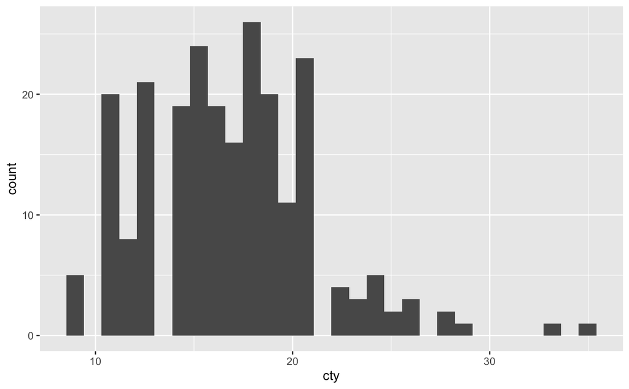

```r
mpg %>%
  ggplot(aes(x = cty)) + # blank canvas: choose the data and the x-axis variable
  geom_histogram() # add geom layer: distribution
```

Faceted histograms with [`facet_wrap()`](https://ggplot2.tidyverse.org/reference/facet_wrap.html):

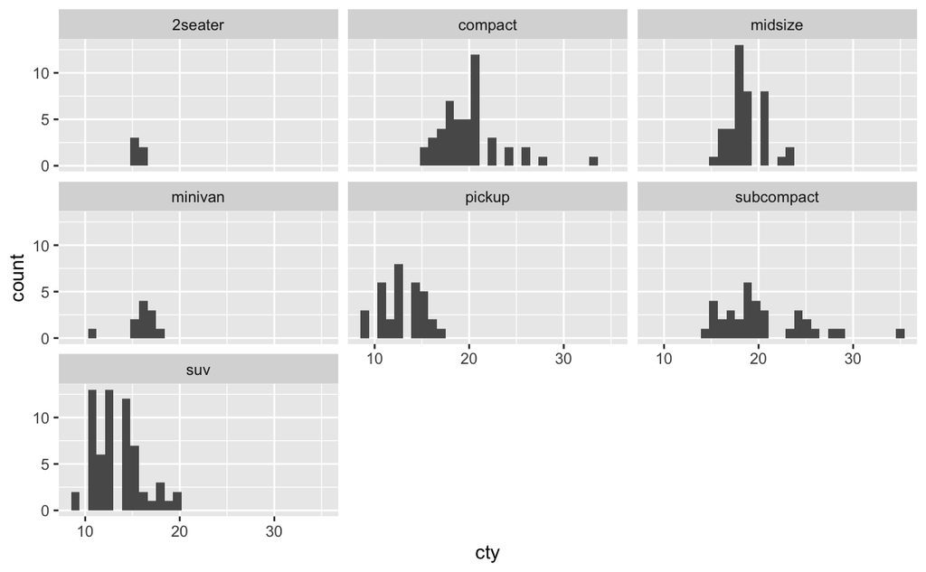

```r
mpg %>%
  ggplot(aes(x = cty)) + # blank canvas: choose the data and the x-axis variable
  geom_histogram() + # add geom layer:  distribution
  facet_wrap(~class) # add facetting (note the "~" before the categorical variable)
```

### 3.1.2 Cumulative distributions

Percentiles and cumulative distributions with `ggplot` and [`stat_ecdf()`](https://ggplot2.tidyverse.org/reference/stat_ecdf.html):

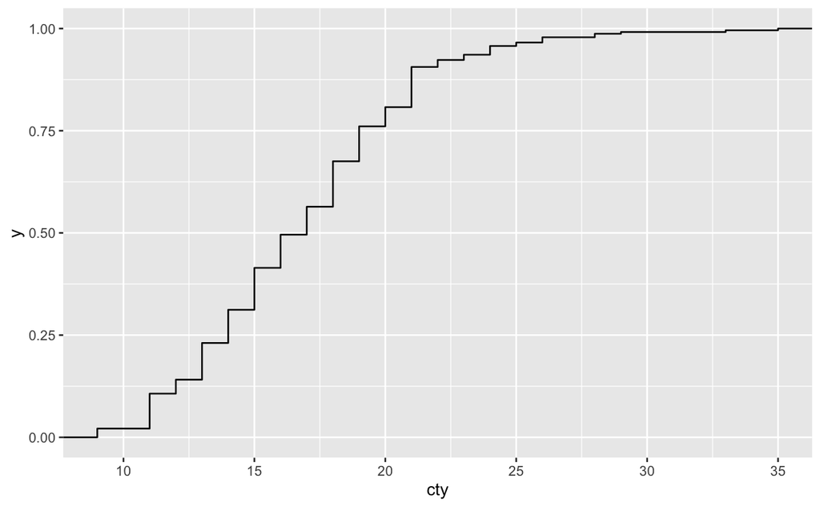

```r
mpg %>%
  ggplot(aes(x=cty)) +  # blank canvas: choose the data and the x-axis variable
  stat_ecdf() # add geom layer: cumulative distribution
```

You can add a vertical line with `geom_vline()` to make it easier to see a percentile. For instance, view percent of cars with less than 15 miles per gallon:

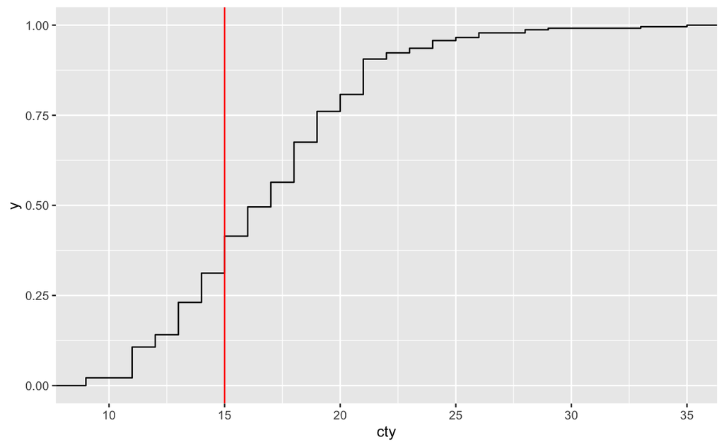

```r
mpg %>%
  ggplot(aes(x=cty)) +  # blank canvas: choose the data and the x-axis variable
  stat_ecdf() + # add geom layer: cumulative distribution
  geom_vline(xintercept = 15, color="red") # verticle
```

### 3.1.3 Box plots

[`geom_boxplot()`](https://ggplot2.tidyverse.org/reference/geom_boxplot.html)

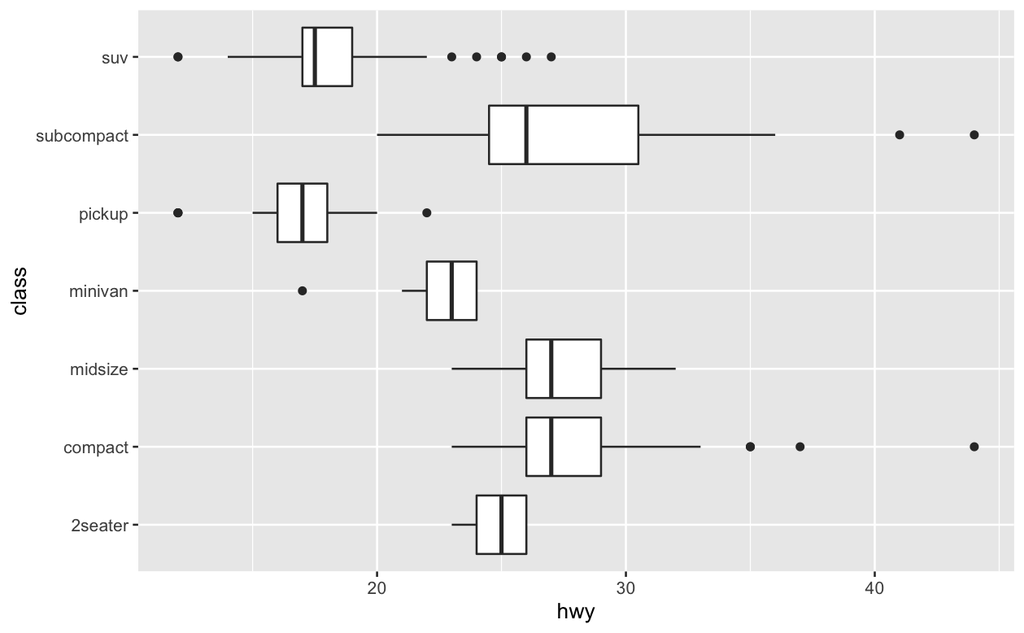

```r
mpg %>%
  ggplot(aes(x = hwy, y = class)) + # x is continuous, y is categorical
  geom_boxplot()
```

or:

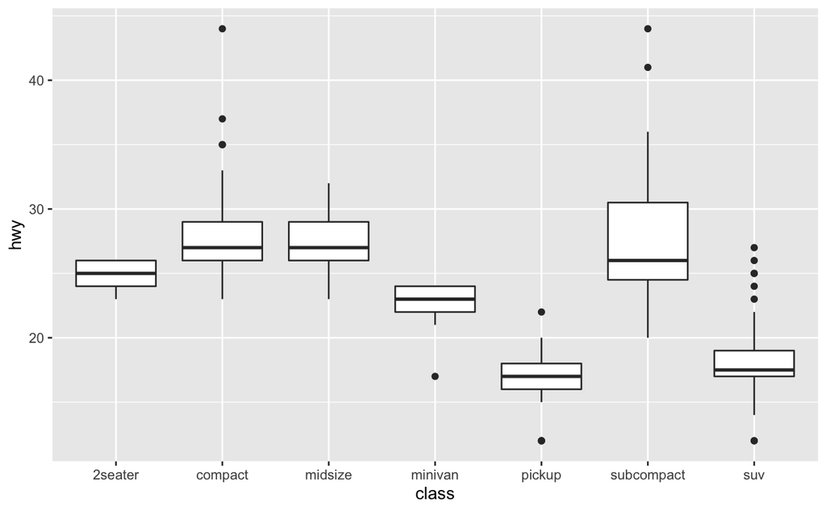

```r
mpg %>%
  ggplot(aes(x = class, y = hwy)) + # x is categorical, y is continuous
  geom_boxplot()
```

## 3.2 Scatterplot

`geom_point()`:

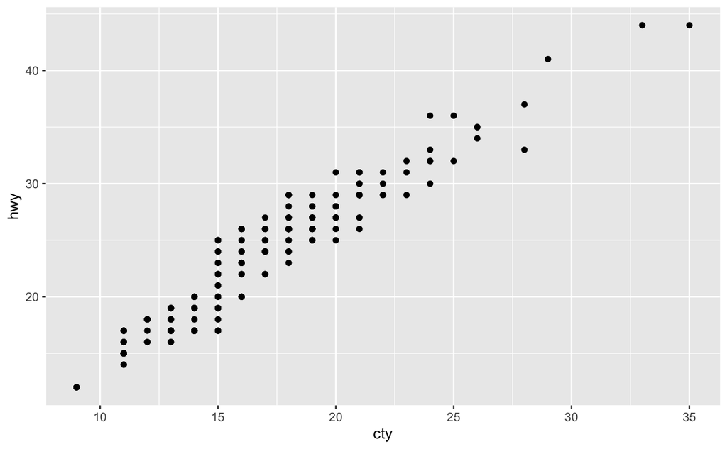

```r
mpg %>%
  ggplot(aes(x = cty, y = hwy)) +
  geom_point()
```

### 3.2.1 Scatterplot with regression line

[`geom_smooth(method = "lm")`](https://ggplot2.tidyverse.org/reference/geom_smooth.html):

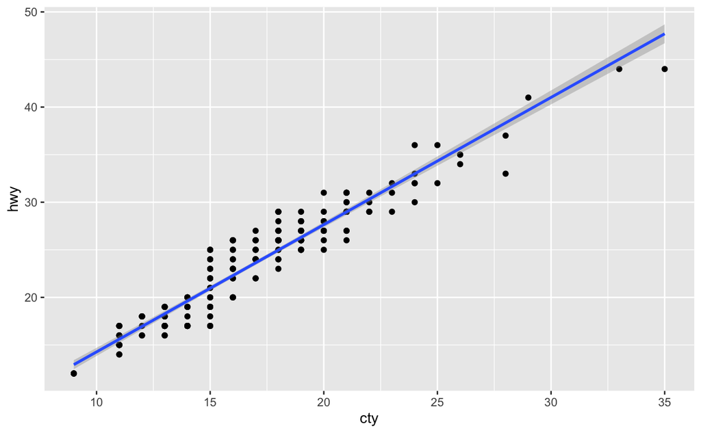

```r
mpg %>%
  ggplot(aes(x = cty, y = hwy)) +
  geom_point() + # scatter-plot
  geom_smooth(method = "lm") # regression line
```

# 4 Correlation and regression

## 4.1 Covariance

`cov()`:

```r
mpg %>%
  summarise(cov(x=cty, y=hwy))
```

| cov(x = cty, y = hwy) |
| --- |
| 24.22543 |

## 4.2 Correlation

`cor()`:

```r
mpg %>%
  summarise(cor(x=cty, y=hwy))
```

| cor(x = cty, y = hwy) |
| --- |
| 0.9559159 |

## 4.3 Regression

`lm()`

Simple linear regression (one $x$ variable):

$$\begin{aligned}
y &= f(x) \\
&= \beta_0 + \beta_1(x) + \epsilon
\end{aligned}$$
In `lm()` the $y$ and $x$ variables are separated by `~`:

```r
mpg %>%
  lm(formula = cty ~ hwy, data = .) # the "." means "use the data from the pipe %>%"
```

```
Call:
lm(formula = cty ~ hwy, data = .)

Coefficients:
(Intercept)          hwy
     0.8442       0.6832
```

Multiple linear regression (multiple $x$ variables):

$$\begin{aligned}
y &= f(\mathbf{X}) \\
&= f(x_1, x_2, \dots) \\
&= \beta_0 + \beta_1(x_1) + \beta_2(x_2) + \dots + \epsilon
\end{aligned}$$
In `lm()` the $x$ variables are separated by `+`:

```r
mpg %>%
  lm(formula = cty ~ hwy + cyl + displ, data = .)
```

```
Call:
lm(formula = cty ~ hwy + cyl + displ, data = .)

Coefficients:
(Intercept)          hwy          cyl        displ
    6.08786      0.58092     -0.44827     -0.05935
```

## 4.4 `summary()`

View hypothesis tests and regression diagnostics with `summary()`:

```r
mpg %>%
  lm(formula = cty ~ hwy + cyl + displ, data = .) %>%
  summary()
```

```
Call:
lm(formula = cty ~ hwy + cyl + displ, data = .)

Residuals:
    Min      1Q  Median      3Q     Max
-3.0347 -0.6012 -0.0229  0.7397  5.2573

Coefficients:
            Estimate Std. Error t value Pr(>|t|)
(Intercept)  6.08786    0.83226   7.315 4.25e-12 ***
hwy          0.58092    0.02010  28.900  < 2e-16 ***
cyl         -0.44827    0.13010  -3.446 0.000677 ***
displ       -0.05935    0.16351  -0.363 0.716971
---
Signif. codes:  0 ‘***’ 0.001 ‘**’ 0.01 ‘*’ 0.05 ‘.’ 0.1 ‘ ’ 1

Residual standard error: 1.148 on 230 degrees of freedom
Multiple R-squared:  0.9281,    Adjusted R-squared:  0.9272
F-statistic: 989.9 on 3 and 230 DF,  p-value: < 2.2e-16
```

## 4.5 Plotting regression results

Use the package `sJplot`. (If you forgot how to install package, see [here](https://lrdegeest.github.io/stats/r.html#3_Install_packages).)

```r
library(sjPlot)
```

The function you want is `plot_model`. The baseline plot shows the coefficients and standard errors:

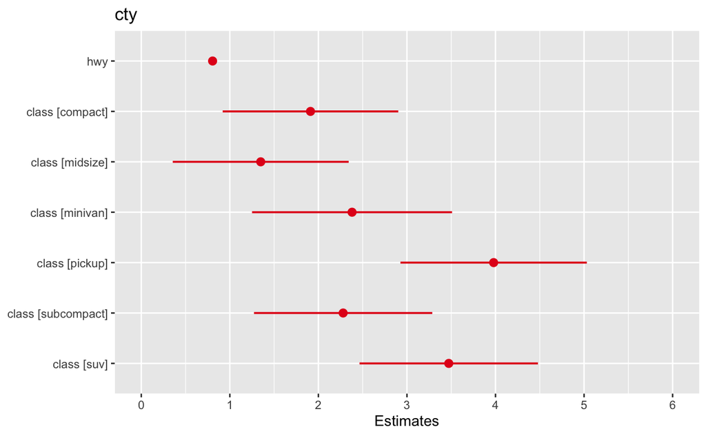

```r
mpg %>%
  lm(formula = cty ~ hwy + class, data = .) %>%
  plot_model(model = .)
```

To plot predicted values you can set `type = "pred"` and then choose which coefficient to plot by setting `terms`:

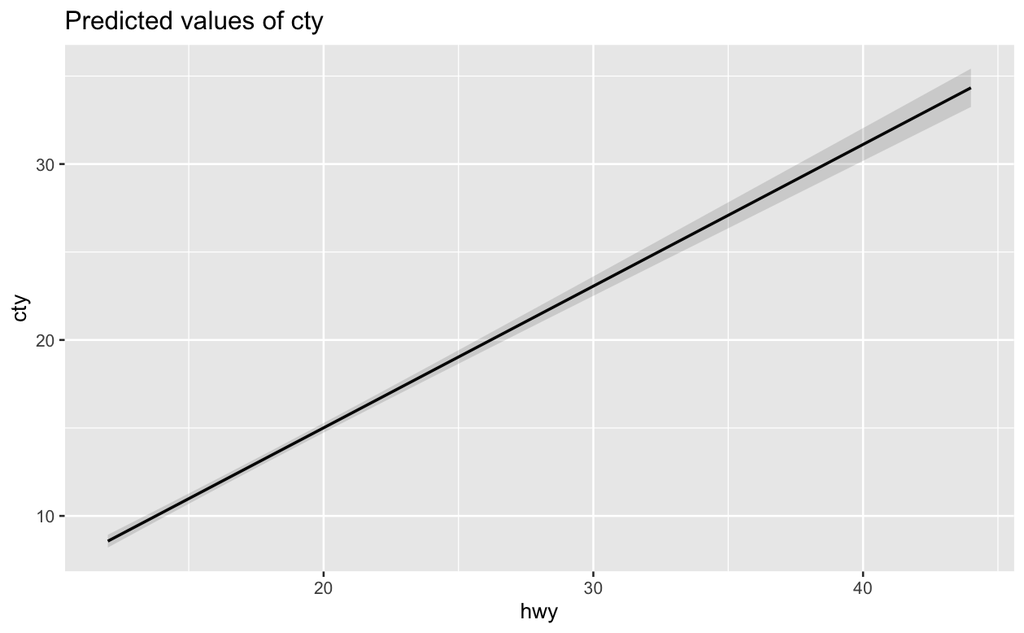

```r
mpg %>%
  lm(formula = cty ~ hwy + class, data = .) %>%
  plot_model(model = ., type = "pred", terms = c("hwy"))
```

The `terms` argument accepts multiple terms:

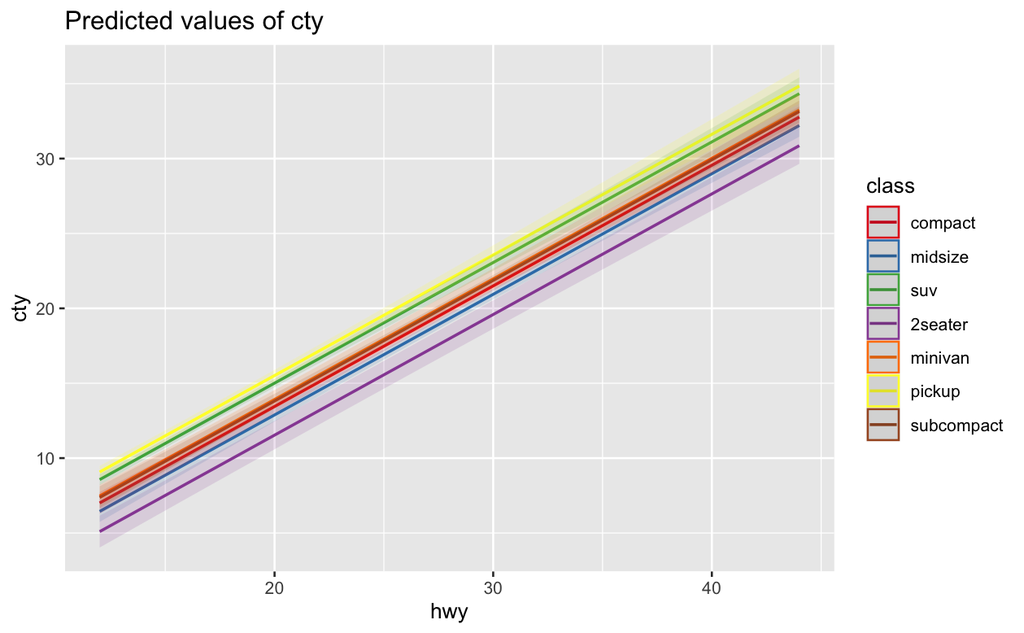

```r
mpg %>%
  lm(formula = cty ~ hwy + class, data = .) %>%
  plot_model(model = ., type = "pred", terms = c("hwy", "class"))
```

This is useful when you have an interaction effect (e.g., `hwy*class`):

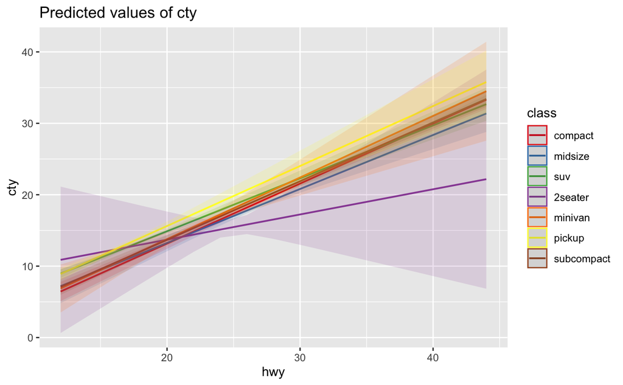

```r
mpg %>%
  lm(formula = cty ~ hwy + class + hwy*class, data = .) %>%
  plot_model(model = ., type = "pred", terms = c("hwy", "class"))
```

`sJplot` uses `ggplot` so you can add `ggplot` stuff to it, like a different theme and titles:

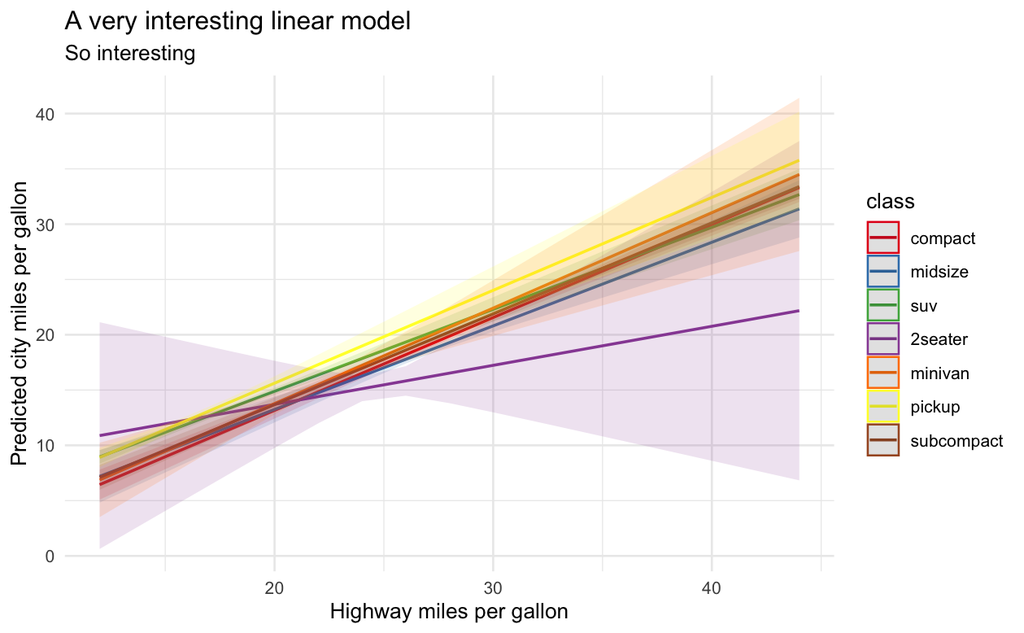

```r
mpg %>%
  lm(formula = cty ~ hwy + class + hwy*class, data = .) %>%
  plot_model(model = ., type = "pred", terms = c("hwy", "class")) +
  labs(x = "Highway miles per gallon", y = "Predicted city miles per gallon",
       title = "A very interesting linear model", subtitle = "So interesting") +
  theme_minimal()
```

The package has tons of great features. Check out the [website!](https://strengejacke.github.io/sjPlot/)

# 5 Quick tables

## 5.1 R

| **Function** | **Description** |
| --- | --- |
| [`%>%`](https://magrittr.tidyverse.org/reference/pipe.html) | Pipe operator (“and then”) |
| [`summarise()`](https://dplyr.tidyverse.org/reference/summarise.html) | Summarize a vector or multiple vectors from a data frame |
| [`mean()`](https://www.rdocumentation.org/packages/base/versions/3.6.2/topics/mean) | Calculate the mean of a vector |
| [`median()`](https://www.rdocumentation.org/packages/stats/versions/3.6.2/topics/median) | Calculate the median of a vector |
| [`sd()`](https://www.rdocumentation.org/packages/stats/versions/3.6.2/topics/sd) | Calculate the standard deviation of a vector |
| [`n()`](https://dplyr.tidyverse.org/reference/n.html) | Count the number of observations. Takes no argument. |
| [`group_by()`](https://dplyr.tidyverse.org/reference/group_by.html) | Group observations by a categorical variable |
| [`select()`](https://dplyr.tidyverse.org/reference/select.html) | Select certain columns |
| [`slice_()`](https://dplyr.tidyverse.org/reference/slice.html) | Slice rows from the data |
| `slice_head(n=5)` | View the head (first five rows) of the data. `n =` can be any number. |
| `slice_max(var, n=5)` | View the rows with the 5 highest values of column “var” |
| `slice_min(var, n=5)` | View the rows with the 5 lowest values of column “var” |
| `slice_sample(n=5)` | Draw 5 rows at random |
| [`filter()`](https://dplyr.tidyverse.org/reference/filter.html) | Filter observations |
| [`mutate()`](https://dplyr.tidyverse.org/reference/mutate.html) | Create a new vector |
| [`cov()`](https://www.rdocumentation.org/packages/pbdDMAT/versions/0.5-1/topics/covariance) | Calculate the covariation between two variables |
| [`cor()`](https://www.rdocumentation.org/packages/stats/versions/3.6.2/topics/cor) | Calculate the correlation between two variables |
| [`lm()`](https://www.rdocumentation.org/packages/stats/versions/3.6.2/topics/lm) | Estimate a linear regression |
| [`ifelse()`](https://www.rdocumentation.org/packages/base/versions/3.6.2/topics/ifelse) | Create a vector based on a “True/False” test |
| [`ggplot()`](https://ggplot2.tidyverse.org/reference/ggplot.html) | Create a base plot |
| [`geom_histogram()`](https://ggplot2.tidyverse.org/reference/geom_histogram.html) | Histogram |
| [`stat_ecdf()`](https://ggplot2.tidyverse.org/reference/stat_ecdf.html) | Cumulative distribution plot |
| [`geom_boxplot()`](https://ggplot2.tidyverse.org/reference/geom_boxplot.html) | Boxplot |
| [`geom_point()`](https://ggplot2.tidyverse.org/reference/geom_point.html) | Scatter plot |
| [`geom_smooth(method = “lm”)`](https://ggplot2.tidyverse.org/reference/geom_smooth.html) | Regression line |

## 5.2 Math

| **Term** | **Meaning** | **Pronunciation** | **Formula/Example** |
| --- | --- | --- | --- |
| $x_i$ | data point $i$ | “x i” |  |
| $n$ | sample size |  |  |
| $N$ | population size |  |  |
| $\bar{x}$ | the sample mean | “x bar” | $\frac{\sum_{i=1}^n x_i}{n}$ |
| $\mu$ | the population mean | “mu” |  |
| $s^2$ | the sample variance |  | $\frac{\sum (x_i - \bar{x})^2}{n-1}$ |
| $\sigma^2$ | the population variance |  |  |
| $s$ | the sample standard deviation |  | $\sqrt{s^2}$ |
| $\sigma$ | the population standard deviation | “sigma” |  |
| $z_i$ | z-score for observation $i$ |  | $z_i = \frac{x_i - \bar{x}}{s}$ |
| $\beta$ | regression coefficient | “beta” | $y = \beta_0 + \beta_1 x + \epsilon$ |
| $\hat{\beta}$ | estimated value of regression coefficient | “beta hat” |  |
| $\epsilon$ | regression error | “epsilon” |  |
| $\sum$ | summation operator | “sum” | $\sum_{i=1}^2 x_i = x_1 + x_2$ |
| $s_{xy}$ | covariation between two variables $x$ and $y$ |  | $\frac{\sum (x_i - \bar{x})(y_i - \bar{y})}{n-1} \in [-\infty,\infty]$ |
| $r_{xy}$ | correlation between two variables $x$ and $y$ |  | $\frac{s_{xy}}{s_x s_y} \in [-1,1]$ |